# Tweets Sentiment Analysis

Howard Nguyen

2022-11-11

### Load dataset

Dataset of donal j trump tweeted from 12/14/2015 to 8/8/2016

### Tweets from iPhone vs Android.

One consideration is what time of day the tweets occur, which we’d expect to be a “signature” of their user. Here we can certainly spot a difference:

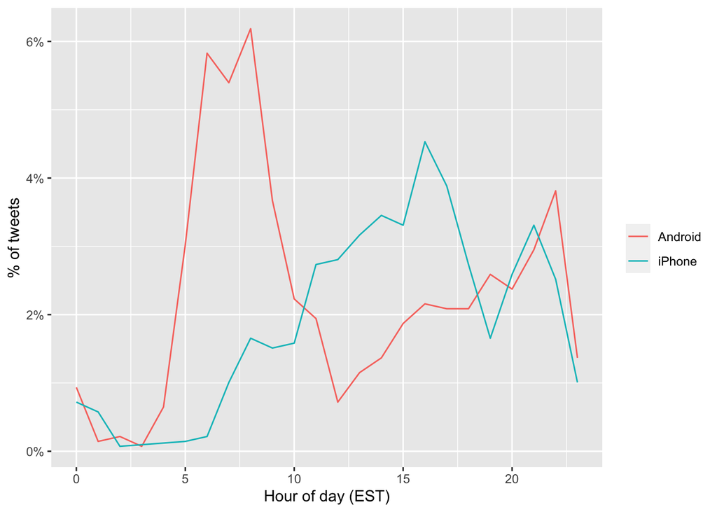

Trump on the Android does a lot more tweeting in the morning, while the campaign posts from the iPhone more in the afternoon and early evening.

Another place we can spot a difference is in Trump’s anachronistic behavior of “manually retweeting” people by copy-pasting their tweets, then surrounding them with quotation marks.

Almost all of these quoted tweets are posted from the Android:

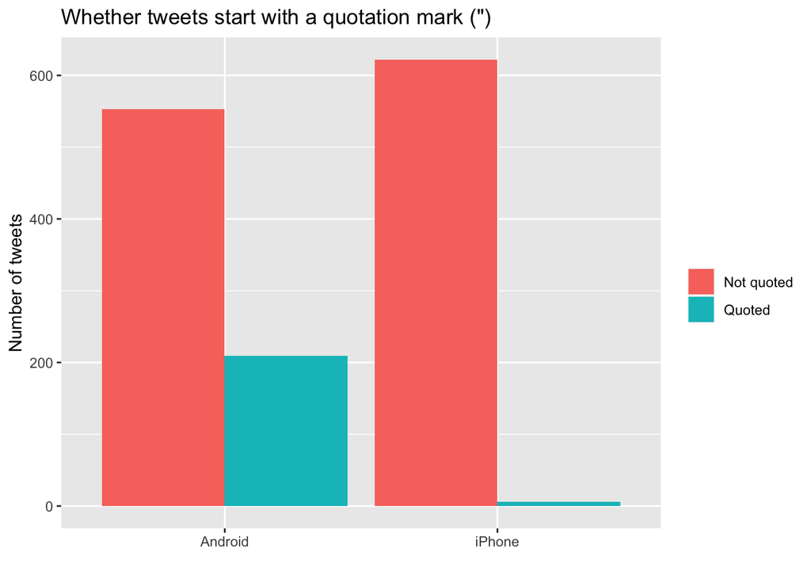

In the remaining by-word analyses in this text, I’ll filter these quoted tweets out (since they contain text from followers that may not be representative of Trump’s own tweets).

Somewhere else we can see a difference involves sharing links or pictures in tweets.

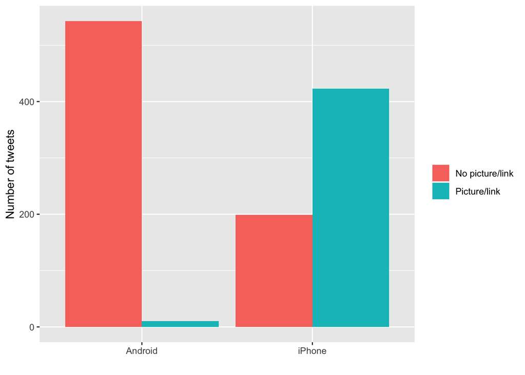

### Comparison of words

Now that we’re sure there’s a difference between these two accounts, what can we say about the difference in the *content*? We’ll use the tidytext package that Julia Silge and David developed.

We start by dividing into individual words using the ‘unnest_tokens’ function, and removing some common stopwords:

| id | source | created | word |
| --- | --- | --- | --- |
| 762669882571980801 | Android | 2016-08-08 15:20:44 | economic |
| 762669882571980801 | Android | 2016-08-08 15:20:44 | policy |
| 762669882571980801 | Android | 2016-08-08 15:20:44 | speech |
| 762669882571980801 | Android | 2016-08-08 15:20:44 | carried |
| 762669882571980801 | Android | 2016-08-08 15:20:44 | live |
| 762669882571980801 | Android | 2016-08-08 15:20:44 | enjoy |
| 762641595439190016 | iPhone | 2016-08-08 13:28:20 | join |
| 762641595439190016 | iPhone | 2016-08-08 13:28:20 | fayetteville |
| 762641595439190016 | iPhone | 2016-08-08 13:28:20 | north |
| 762641595439190016 | iPhone | 2016-08-08 13:28:20 | carolina |

[output cut: 8743 more lines]

### What were the most common words in Trump’s tweets overall?

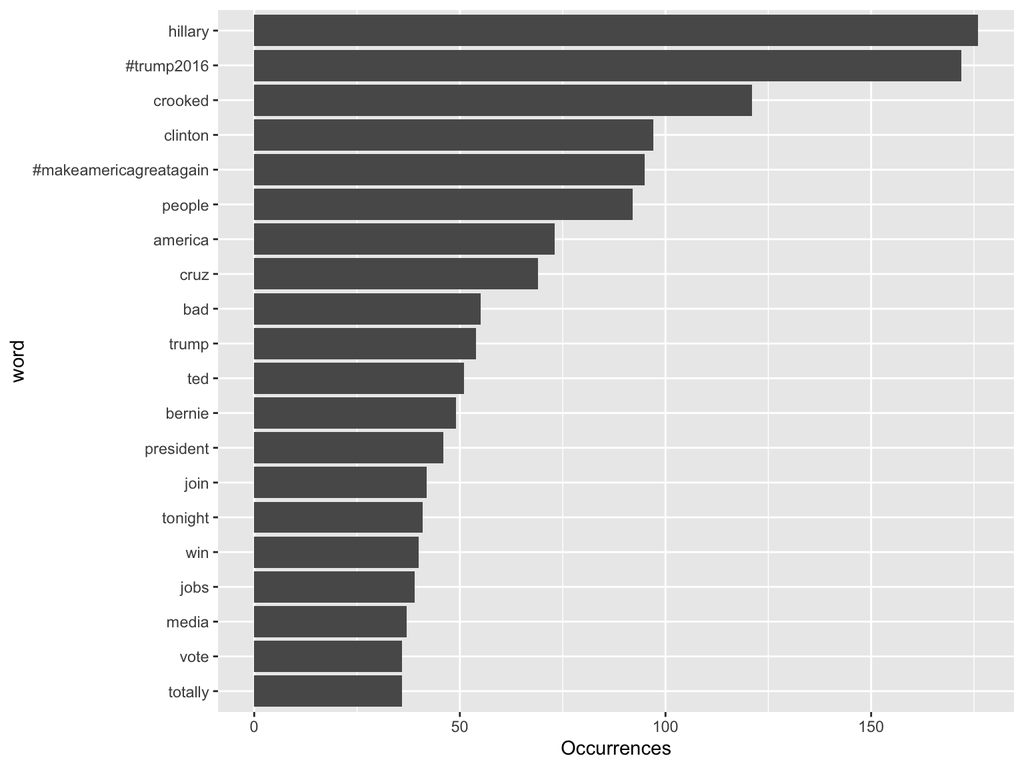

These should look familiar for anyone who has seen the feed. Now let’s consider which words are most common from the Android relative to the iPhone, and vice versa. We’ll use the simple measure of log odds ratio, calculated for each word.

### Which are the words most likely to be from Android and most likely from iPhone?

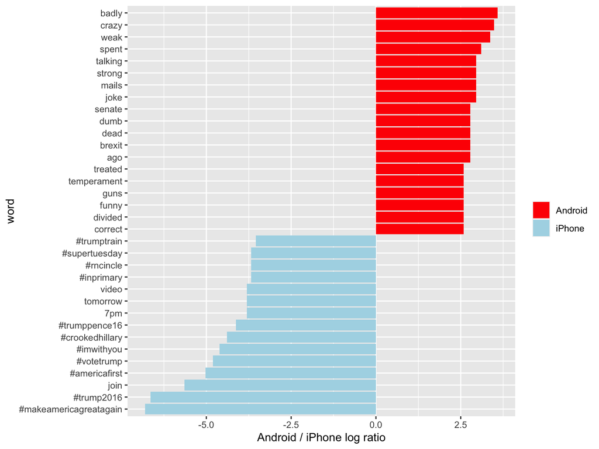

A few observations:

- **Most hashtags come from the iPhone**. Indeed, almost no tweets from Trump’s Android contained hashtags, with some rare exceptions like [this one](https://twitter.com/realDonaldTrump/status/753960134422900736). (This is true only because we filtered out the quoted “retweets”, as Trump does sometimes quote tweets [like this](https://twitter.com/realDonaldTrump/status/731805331425218560) that contain hashtags).
- **Words like “join” and “tomorrow”, and times like “7pm”, also came only from the iPhone**. The iPhone is clearly responsible for event announcements like [this one](https://twitter.com/realDonaldTrump/status/743522630230228993) (“Join me in Houston, Texas tomorrow night at 7pm!”)
- **A lot of “emotionally charged” words, like “badly”, “crazy”, “weak”, and “dumb”, were overwhelmingly more common on Android.** This supports the original hypothesis that this is the “angrier” or more hyperbolic account.

### Sentiment analysis: Trump’s tweets are much more negative than his campaign’s

Since we’ve observed a difference in sentiment between the Android and iPhone tweets, let’s try quantifying it. We’ll work with the [NRC Word-Emotion Association](http://saifmohammad.com/WebPages/NRC-Emotion-Lexicon.htm) lexicon, available from the tidytext package, which associates words with 10 sentiments: **positive**, **negative**, **anger**, **anticipation**, **disgust**, **fear**, **joy**, **sadness**, **surprise**, and **trust**.

```r
nrc <- get_sentiments("nrc")
nrc
```

| word | sentiment |
| --- | --- |
| abacus | trust |
| abandon | fear |
| abandon | negative |
| abandon | sadness |
| abandoned | anger |
| abandoned | fear |
| abandoned | negative |
| abandoned | sadness |
| abandonment | anger |
| abandonment | fear |

[output cut: 9990 more lines]

### Sentiment Analysis

To measure the sentiment of the Android and iPhone tweets, we can count the number of words in each category:

| source | sentiment | total_words | words |
| --- | --- | --- | --- |
| Android | anger | 4901 | 321 |
| Android | anticipation | 4901 | 256 |
| Android | disgust | 4901 | 207 |
| Android | fear | 4901 | 268 |
| Android | joy | 4901 | 199 |
| Android | negative | 4901 | 560 |

| sentiment | estimate | statistic | p.value | parameter | conf.low | conf.high | method | alternative |
| --- | --- | --- | --- | --- | --- | --- | --- | --- |
| anger | 1.492863 | 321 | 2.193242e-05 | 274.3619 | 1.2353162 | 1.809371 | Comparison of Poisson rates | two.sided |
| anticipation | 1.176645 | 256 | 1.076095e-01 | 239.0868 | 0.9657865 | 1.436449 | Comparison of Poisson rates | two.sided |
| disgust | 1.712570 | 207 | 9.591943e-06 | 169.0965 | 1.3369430 | 2.207126 | Comparison of Poisson rates | two.sided |
| fear | 1.560280 | 268 | 1.886129e-05 | 225.6487 | 1.2640494 | 1.933386 | Comparison of Poisson rates | two.sided |
| joy | 1.009074 | 199 | 9.573330e-01 | 198.2125 | 0.8138472 | 1.253011 | Comparison of Poisson rates | two.sided |
| negative | 1.705964 | 560 | 3.910439e-13 | 458.0165 | 1.4694294 | 1.984805 | Comparison of Poisson rates | two.sided |
| positive | 1.061336 | 555 | 3.643714e-01 | 540.8850 | 0.9325539 | 1.208673 | Comparison of Poisson rates | two.sided |
| sadness | 1.620044 | 303 | 1.150493e-06 | 251.9650 | 1.3260252 | 1.986518 | Comparison of Poisson rates | two.sided |
| surprise | 1.167925 | 159 | 2.174483e-01 | 148.9393 | 0.9083517 | 1.506593 | Comparison of Poisson rates | two.sided |
| trust | 1.132891 | 369 | 1.259542e-01 | 349.9514 | 0.9633205 | 1.333947 | Comparison of Poisson rates | two.sided |

### Visualize sentiment analysis with a 95% confidence interval:

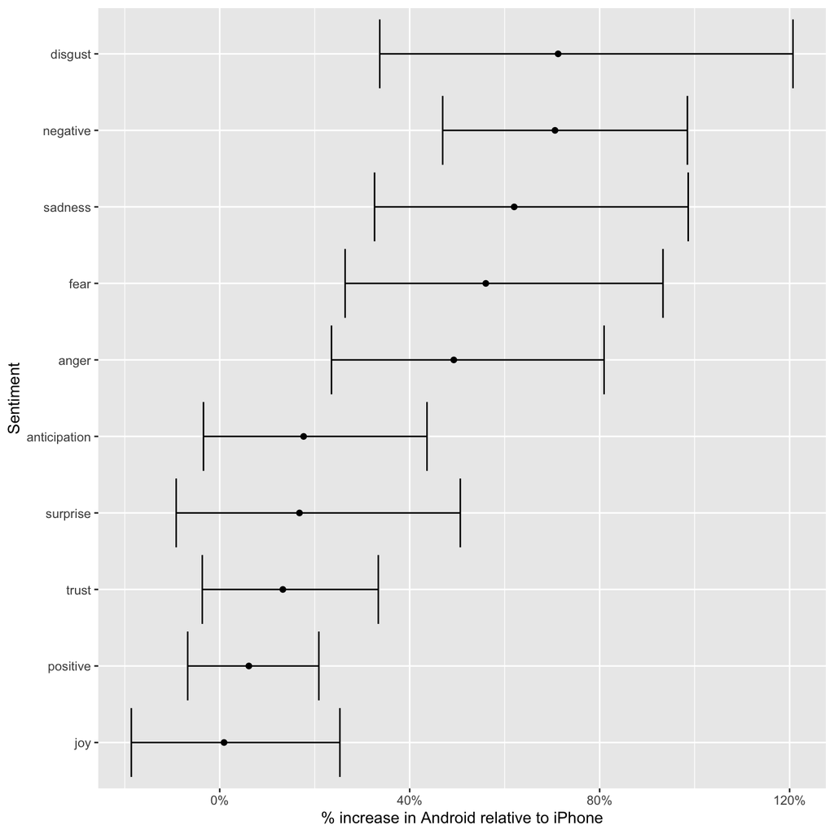

Thus, Trump’s Android account uses about 40-80% more words related to **disgust**, **sadness**, **fear**, **anger**, and other “negative” sentiments than the iPhone account does. (The positive emotions weren’t different to a statistically significant extent).

We’re especially interested in which words drove this different in sentiment. Let’s consider the words with the largest changes within each category:

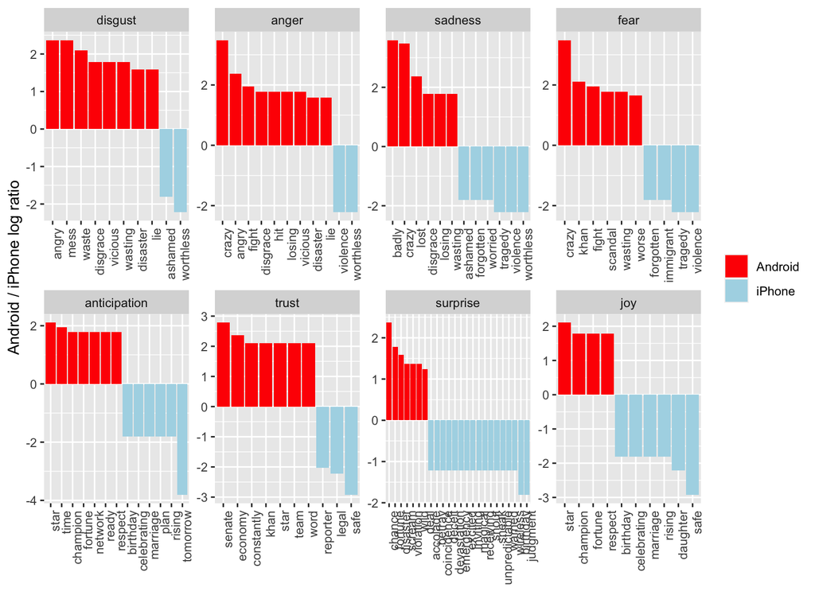

Reference: Text Analysis of Trump’s tweets confirms he writes only the (angier) Android half, David Robinson, Director of Data Scientist at Heap.